# **Homework 1**

Kevin Ha

September 2nd, 2021

### **Problem 1**

##### *Problem 1.1*

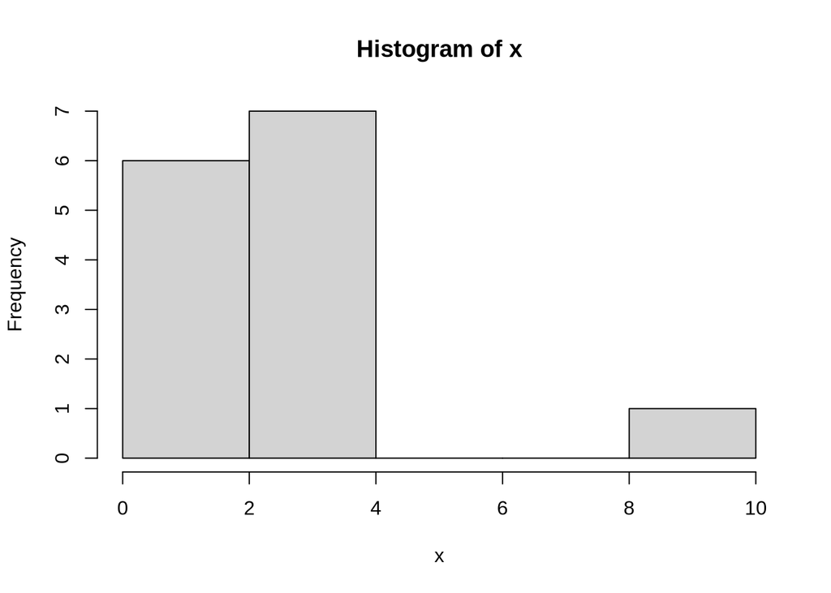

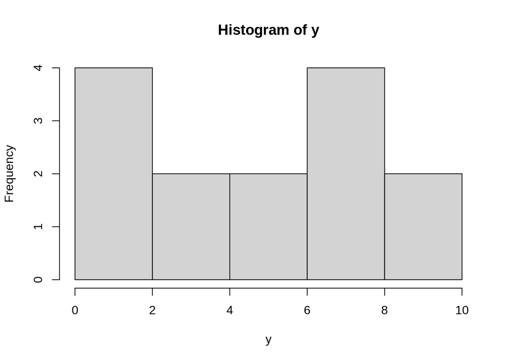

##### *Problem 1.2*

```r
summary(x)
```

```
##    Min. 1st Qu.  Median    Mean 3rd Qu.    Max.
##   0.200   1.275   2.250   2.407   2.900   9.000
```

```r
var(x)
```

```
## [1] 4.568407
```

```r
summary(y)
```

```
##    Min. 1st Qu.  Median    Mean 3rd Qu.    Max.
##   0.100   1.400   5.300   4.871   7.575   9.800
```

```r
var(y)
```

```
## [1] 11.17143
```

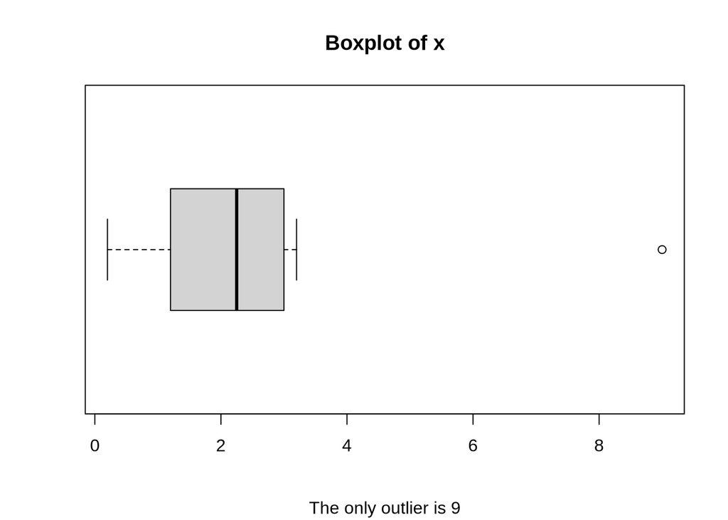

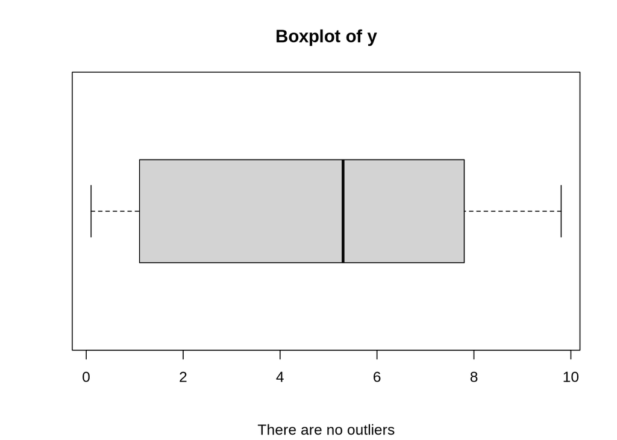

##### *Problem 1.3*

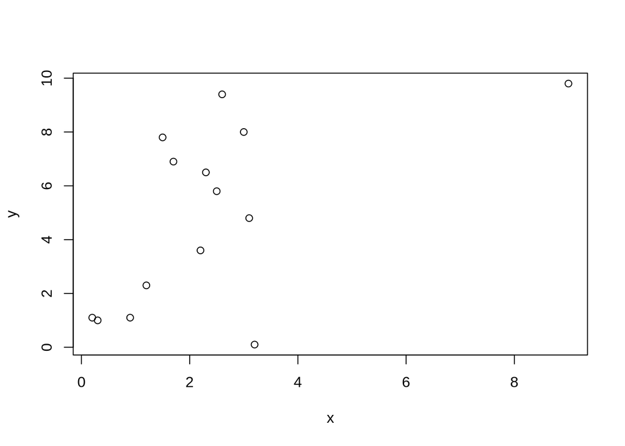

```r
cor(x,y)
```

```
## [1] 0.5679153
```

**The correlation coefficient presents that there is neither a weak or strong linear association between $x_i$ and $y_i$**

##### *Problem 1.4*

Yes, the outlier is the pair **(9.0, 9.8)** since the first coordinator (x) was previously identified as an outlier for all $x_i$’s.

Removing the pair produces the following correlation coefficient:

```
## [1] 0.4586256
```

##### *Problem 1.5*

Upon removing the outlier in Problem 1.4, the correlation coefficient decreased and **weakened** the linear association between $x_i$ and $y_i$.

##### *Problem 1.6*

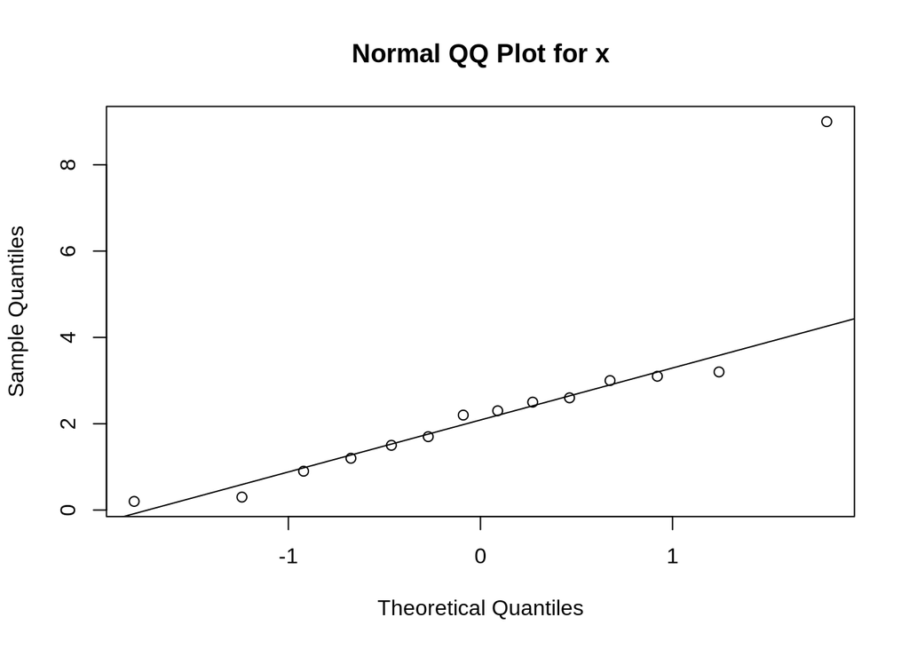

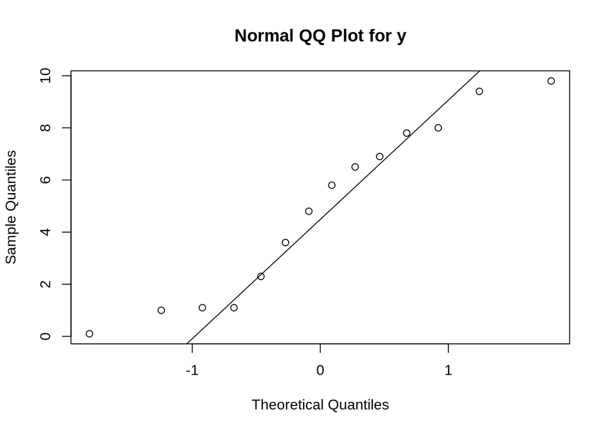

### Problem 2

Given that $F$ is the cdf for the random variable $X$, $F^{-1}(\alpha)$ is the inverse cdf or quantile function which determines the x value that is needed to achieve the probability $\alpha$. With this in mind, the following probabilities can be determined:

$P(X \leq F^{-1}(\alpha/2)) = \alpha/2$  
$P(X \leq F^{-1}(1-\alpha/2)) = 1 - \alpha/2$  
$P(F^{-1}(\alpha/2) \leq X \leq F^{-1}(1 - \alpha/2)) = (1 - \alpha/2 - \alpha/2) = 1 - \frac{2\alpha}{2} = 1 - \alpha$

Given that $X \sim N(0,1)$ this establishes that X is normally distributed with a $\mu = 0$ and $\sigma = 1$, which is a standard normal distribution.

To calculate the following `qnorm()` will be used with $\mu = 0$ and $\sigma = 1$

$P (X \leq z_{0.05})$, given $\alpha = 0.05$, the z-score $1-\alpha$ needs to be found.

```r
qnorm(1-0.05, 0, 1)
```

```
## [1] 1.644854
```

$P (X \leq z_{0.05}) = P(Z \leq 1.644854) = 0.95$

$P (X \leq z_{1-0.05/2})$, given $\alpha = 1-0.05/2$, the z-score $1-\alpha$ needs to be found.

```r
qnorm(1-0.975, 0, 1)
```

```
## [1] -1.959964
```

$P (X \leq z_{1-0.05/2}) = P(Z \leq -1.959964) = 0.025$

$P (z_{0.05/2} \leq X \leq z_{1-0.05/2})$

$P (z_{0.05/2})$ given $\alpha = 0.05/2$, the z-score $1-\alpha$ needs to be found.

```r
qnorm(1- 0.025, 0, 1)
```

```
## [1] 1.959964
```

$P (z_{0.05/2} \leq X \leq z_{1-0.05/2}) = 0.975 - 0.025 = 0.95$

### Problem 3

Verify using algebraic manipulation:
$$\frac{1}{n} \sum_{i=1}^{n} (x_i - \overline{x})^2 = \frac{1}{n} \sum_{i=1}^{n} x_i^2 - \overline{x}^2$$
1. Expand out $\frac{1}{n} \sum_{i=1}^{n} (x_i - \overline{x})^2$ to $\frac{1}{n} \sum_{i=1}^{n} (x_i^2 - 2x_i\overline{x} + \overline{x})$
2. $\frac{1}{n} \sum_{i=1}^{n} (x_i^2 - 2x_i\mu + \overline{x})$ is equivalent to $\frac{\sum_{i=1}^{n} x_i^2 - 2\overline{x}\sum_{i=1}^{n} x_i + \overline{x}^2 \sum_{i=1}^{n} 1} {n}$
3. $\sum_{i=1}^{n} 1$ is the same as adding 1, $n$ times and can be reduced to just $n$.
4. Simplified more: $\frac{\sum_{i=1}^{n} x_i^2}{n} - \frac{2\overline{x}\sum_{i=1}^{n} x_i}{n} + \frac{\overline{x}^2 n}{n}$
5. $\frac{\sum_{i=1}^{n} x_i}{n}$ is the population mean and can be reduced to just $\overline{x}$
6. Lastly, the simplifications result in: $\frac{\sum_{i=1}^{n} x_i^2}{n} - 2\overline{x}^2 + \overline{x}^2 = \frac{1}{n}{\sum_{i=1}^{n} x_i^2} - \overline{x}^2$, verifying equivalency.